# Risk Factor Analysis

## Outcome Variable

**Outcome Variable:** ever_co

## Predictor Variables

**Intervention Variable:** exclfeed3

**Adjustment Set:**

- arm
- sex
- W_mage
- meducyrs
- feducyrs
- hhwealth_quart
- hfoodsec
- W_mhtcm
- vagbrth
- W_gagebrth
- W_birthwt
- W_birthlen
- W_nrooms
- W_nchldlt5
- month
- brthmon
- W_parity
- impfloor
- impsan
- safeh20
- delta_W_mage
- delta_meducyrs
- delta_feducyrs
- delta_hhwealth_quart
- delta_hfoodsec
- delta_W_mhtcm
- delta_vagbrth
- delta_W_gagebrth
- delta_W_birthwt
- delta_W_birthlen
- delta_W_nrooms
- delta_W_nchldlt5
- delta_month
- delta_brthmon
- delta_W_parity
- delta_impfloor
- delta_impsan
- delta_safeh20

## Stratifying Variables

The analysis was stratified on these variable(s):

- agecat
- studyid
- country

## Data Summary

| agecat | studyid | country | exclfeed3 | ever_co | n_cell | n |
| --- | --- | --- | --- | --- | --- | --- |
| 0-24 months | ki0047075b-MAL-ED | BANGLADESH | 1 | 0 | 149 | 248 |
| 0-24 months | ki0047075b-MAL-ED | BANGLADESH | 1 | 1 | 32 | 248 |
| 0-24 months | ki0047075b-MAL-ED | BANGLADESH | 0 | 0 | 61 | 248 |
| 0-24 months | ki0047075b-MAL-ED | BANGLADESH | 0 | 1 | 6 | 248 |
| 0-24 months | ki0047075b-MAL-ED | BRAZIL | 1 | 0 | 84 | 225 |
| 0-24 months | ki0047075b-MAL-ED | BRAZIL | 1 | 1 | 1 | 225 |
| 0-24 months | ki0047075b-MAL-ED | BRAZIL | 0 | 0 | 139 | 225 |
| 0-24 months | ki0047075b-MAL-ED | BRAZIL | 0 | 1 | 1 | 225 |
| 0-24 months | ki0047075b-MAL-ED | INDIA | 1 | 0 | 116 | 240 |
| 0-24 months | ki0047075b-MAL-ED | INDIA | 1 | 1 | 30 | 240 |
| 0-24 months | ki0047075b-MAL-ED | INDIA | 0 | 0 | 70 | 240 |
| 0-24 months | ki0047075b-MAL-ED | INDIA | 0 | 1 | 24 | 240 |
| 0-24 months | ki0047075b-MAL-ED | NEPAL | 1 | 0 | 76 | 235 |
| 0-24 months | ki0047075b-MAL-ED | NEPAL | 1 | 1 | 10 | 235 |
| 0-24 months | ki0047075b-MAL-ED | NEPAL | 0 | 0 | 139 | 235 |
| 0-24 months | ki0047075b-MAL-ED | NEPAL | 0 | 1 | 10 | 235 |
| 0-24 months | ki0047075b-MAL-ED | PERU | 1 | 0 | 67 | 286 |
| 0-24 months | ki0047075b-MAL-ED | PERU | 1 | 1 | 3 | 286 |
| 0-24 months | ki0047075b-MAL-ED | PERU | 0 | 0 | 208 | 286 |
| 0-24 months | ki0047075b-MAL-ED | PERU | 0 | 1 | 8 | 286 |
| 0-24 months | ki0047075b-MAL-ED | SOUTH AFRICA | 1 | 0 | 34 | 275 |
| 0-24 months | ki0047075b-MAL-ED | SOUTH AFRICA | 1 | 1 | 0 | 275 |
| 0-24 months | ki0047075b-MAL-ED | SOUTH AFRICA | 0 | 0 | 220 | 275 |
| 0-24 months | ki0047075b-MAL-ED | SOUTH AFRICA | 0 | 1 | 21 | 275 |
| 0-24 months | ki0047075b-MAL-ED | TANZANIA, UNITED REPUBLIC OF | 1 | 0 | 65 | 249 |
| 0-24 months | ki0047075b-MAL-ED | TANZANIA, UNITED REPUBLIC OF | 1 | 1 | 4 | 249 |
| 0-24 months | ki0047075b-MAL-ED | TANZANIA, UNITED REPUBLIC OF | 0 | 0 | 161 | 249 |
| 0-24 months | ki0047075b-MAL-ED | TANZANIA, UNITED REPUBLIC OF | 0 | 1 | 19 | 249 |
| 0-24 months | ki1000108-CMC-V-BCS-2002 | INDIA | 1 | 0 | 7 | 10 |
| 0-24 months | ki1000108-CMC-V-BCS-2002 | INDIA | 1 | 1 | 3 | 10 |

[output cut: 162 more lines]

The following strata were considered:

- agecat: 0-24 months, studyid: ki0047075b-MAL-ED, country: BANGLADESH
- agecat: 0-24 months, studyid: ki0047075b-MAL-ED, country: BRAZIL
- agecat: 0-24 months, studyid: ki0047075b-MAL-ED, country: INDIA
- agecat: 0-24 months, studyid: ki0047075b-MAL-ED, country: NEPAL
- agecat: 0-24 months, studyid: ki0047075b-MAL-ED, country: PERU
- agecat: 0-24 months, studyid: ki0047075b-MAL-ED, country: SOUTH AFRICA
- agecat: 0-24 months, studyid: ki0047075b-MAL-ED, country: TANZANIA, UNITED REPUBLIC OF
- agecat: 0-24 months, studyid: ki1000108-CMC-V-BCS-2002, country: INDIA
- agecat: 0-24 months, studyid: ki1000108-IRC, country: INDIA
- agecat: 0-24 months, studyid: ki1000109-EE, country: PAKISTAN
- agecat: 0-24 months, studyid: ki1000304b-SAS-CompFeed, country: INDIA
- agecat: 0-24 months, studyid: ki1017093b-PROVIDE, country: BANGLADESH
- agecat: 0-24 months, studyid: ki1101329-Keneba, country: GAMBIA
- agecat: 0-24 months, studyid: ki1113344-GMS-Nepal, country: NEPAL
- agecat: 0-24 months, studyid: kiGH5241-JiVitA-3, country: BANGLADESH
- agecat: 0-24 months, studyid: kiGH5241-JiVitA-4, country: BANGLADESH
- agecat: 0-6 months, studyid: ki0047075b-MAL-ED, country: BANGLADESH
- agecat: 0-6 months, studyid: ki0047075b-MAL-ED, country: BRAZIL
- agecat: 0-6 months, studyid: ki0047075b-MAL-ED, country: INDIA
- agecat: 0-6 months, studyid: ki0047075b-MAL-ED, country: NEPAL
- agecat: 0-6 months, studyid: ki0047075b-MAL-ED, country: PERU
- agecat: 0-6 months, studyid: ki0047075b-MAL-ED, country: SOUTH AFRICA
- agecat: 0-6 months, studyid: ki0047075b-MAL-ED, country: TANZANIA, UNITED REPUBLIC OF
- agecat: 0-6 months, studyid: ki1000108-CMC-V-BCS-2002, country: INDIA
- agecat: 0-6 months, studyid: ki1000108-IRC, country: INDIA
- agecat: 0-6 months, studyid: ki1000109-EE, country: PAKISTAN
- agecat: 0-6 months, studyid: ki1000304b-SAS-CompFeed, country: INDIA
- agecat: 0-6 months, studyid: ki1017093b-PROVIDE, country: BANGLADESH
- agecat: 0-6 months, studyid: ki1101329-Keneba, country: GAMBIA
- agecat: 0-6 months, studyid: ki1113344-GMS-Nepal, country: NEPAL
- agecat: 0-6 months, studyid: kiGH5241-JiVitA-3, country: BANGLADESH
- agecat: 0-6 months, studyid: kiGH5241-JiVitA-4, country: BANGLADESH
- agecat: 6-24 months, studyid: ki0047075b-MAL-ED, country: BANGLADESH
- agecat: 6-24 months, studyid: ki0047075b-MAL-ED, country: BRAZIL
- agecat: 6-24 months, studyid: ki0047075b-MAL-ED, country: INDIA
- agecat: 6-24 months, studyid: ki0047075b-MAL-ED, country: NEPAL
- agecat: 6-24 months, studyid: ki0047075b-MAL-ED, country: PERU
- agecat: 6-24 months, studyid: ki0047075b-MAL-ED, country: SOUTH AFRICA
- agecat: 6-24 months, studyid: ki0047075b-MAL-ED, country: TANZANIA, UNITED REPUBLIC OF
- agecat: 6-24 months, studyid: ki1000108-CMC-V-BCS-2002, country: INDIA
- agecat: 6-24 months, studyid: ki1000108-IRC, country: INDIA
- agecat: 6-24 months, studyid: ki1000109-EE, country: PAKISTAN
- agecat: 6-24 months, studyid: ki1000304b-SAS-CompFeed, country: INDIA
- agecat: 6-24 months, studyid: ki1017093b-PROVIDE, country: BANGLADESH
- agecat: 6-24 months, studyid: ki1101329-Keneba, country: GAMBIA
- agecat: 6-24 months, studyid: ki1113344-GMS-Nepal, country: NEPAL
- agecat: 6-24 months, studyid: kiGH5241-JiVitA-3, country: BANGLADESH
- agecat: 6-24 months, studyid: kiGH5241-JiVitA-4, country: BANGLADESH

### Dropped Strata

Some strata were dropped due to rare outcomes:

- agecat: 0-24 months, studyid: ki0047075b-MAL-ED, country: BRAZIL
- agecat: 0-24 months, studyid: ki0047075b-MAL-ED, country: PERU
- agecat: 0-24 months, studyid: ki0047075b-MAL-ED, country: SOUTH AFRICA
- agecat: 0-24 months, studyid: ki0047075b-MAL-ED, country: TANZANIA, UNITED REPUBLIC OF
- agecat: 0-24 months, studyid: ki1000108-CMC-V-BCS-2002, country: INDIA
- agecat: 0-24 months, studyid: ki1000108-IRC, country: INDIA
- agecat: 0-24 months, studyid: kiGH5241-JiVitA-4, country: BANGLADESH
- agecat: 0-6 months, studyid: ki0047075b-MAL-ED, country: BANGLADESH
- agecat: 0-6 months, studyid: ki0047075b-MAL-ED, country: BRAZIL
- agecat: 0-6 months, studyid: ki0047075b-MAL-ED, country: NEPAL
- agecat: 0-6 months, studyid: ki0047075b-MAL-ED, country: PERU
- agecat: 0-6 months, studyid: ki0047075b-MAL-ED, country: SOUTH AFRICA
- agecat: 0-6 months, studyid: ki0047075b-MAL-ED, country: TANZANIA, UNITED REPUBLIC OF
- agecat: 0-6 months, studyid: ki1000108-CMC-V-BCS-2002, country: INDIA
- agecat: 0-6 months, studyid: ki1000108-IRC, country: INDIA
- agecat: 0-6 months, studyid: ki1000304b-SAS-CompFeed, country: INDIA
- agecat: 0-6 months, studyid: kiGH5241-JiVitA-4, country: BANGLADESH
- agecat: 6-24 months, studyid: ki0047075b-MAL-ED, country: BRAZIL
- agecat: 6-24 months, studyid: ki0047075b-MAL-ED, country: PERU
- agecat: 6-24 months, studyid: ki0047075b-MAL-ED, country: SOUTH AFRICA
- agecat: 6-24 months, studyid: ki0047075b-MAL-ED, country: TANZANIA, UNITED REPUBLIC OF
- agecat: 6-24 months, studyid: ki1000108-CMC-V-BCS-2002, country: INDIA
- agecat: 6-24 months, studyid: ki1000108-IRC, country: INDIA
- agecat: 6-24 months, studyid: kiGH5241-JiVitA-4, country: BANGLADESH

## Methods Detail

We’re interested in the causal parameters $E[Y_a]$ for all values of $a \in \mathcal{A}$. These parameters represent the mean outcome if, possibly contrary to fact, we intervened to set all units to have $A=a$. Under the randomization and positivity assumptions, these are identified by the statistical parameters $\psi_a=E_W[E_{Y|A,W}(Y|A=a,W)]$. In addition, we’re interested in the mean of $Y$, $E[Y]$ under no intervention (the observed mean). We will estimate these parameters by using SuperLearner to fit the relevant likelihood factors – $E_{Y|A,W}(Y|A=a,W)$ and $p(A=a|W)$, and then updating our likelihood fit using a joint TMLE.

For unadjusted analyses ($W=\{\}$), initial likelihoods were estimated using Lrnr_glm to estimate the simple $E(Y|A)$ and Lrnr_mean to estimate $p(A)$. For adjusted analyses, a small library containing Lrnr_glmnet, Lrnr_xgboost, and Lrnr_mean was used.

Having estimated these parameters, we will then use the delta method to estimate relative risks and attributable risks relative to a prespecified baseline level of $A$.

# Results Detail

## Results Plots

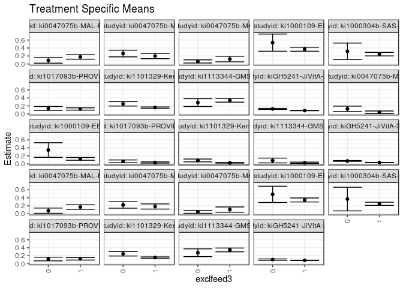

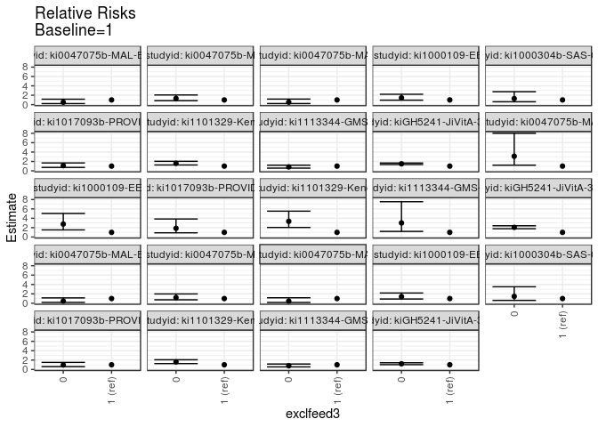

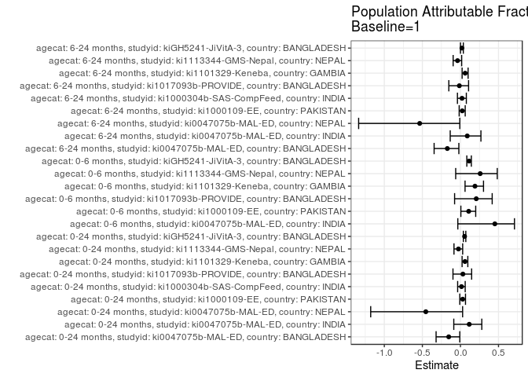

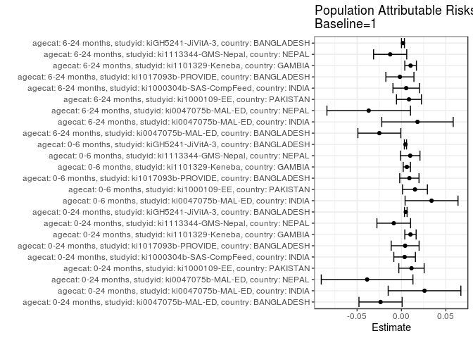

## Results Table

### Parameter: TSM

| agecat | studyid | country | intervention_level | baseline_level | estimate | ci_lower | ci_upper |
| --- | --- | --- | --- | --- | --- | --- | --- |
| 0-24 months | ki0047075b-MAL-ED | BANGLADESH | 1 | NA | 0.1767956 | 0.1211058 | 0.2324854 |
| 0-24 months | ki0047075b-MAL-ED | BANGLADESH | 0 | NA | 0.0895522 | 0.0210423 | 0.1580622 |
| 0-24 months | ki0047075b-MAL-ED | INDIA | 1 | NA | 0.1990082 | 0.1337494 | 0.2642670 |
| 0-24 months | ki0047075b-MAL-ED | INDIA | 0 | NA | 0.2620808 | 0.1781341 | 0.3460274 |
| 0-24 months | ki0047075b-MAL-ED | NEPAL | 1 | NA | 0.1238126 | 0.0538607 | 0.1937645 |
| 0-24 months | ki0047075b-MAL-ED | NEPAL | 0 | NA | 0.0638572 | 0.0242591 | 0.1034553 |
| 0-24 months | ki1000109-EE | PAKISTAN | 1 | NA | 0.3696518 | 0.3191541 | 0.4201495 |
| 0-24 months | ki1000109-EE | PAKISTAN | 0 | NA | 0.5342458 | 0.3197328 | 0.7487587 |
| 0-24 months | ki1000304b-SAS-CompFeed | INDIA | 1 | NA | 0.2464455 | 0.2022875 | 0.2906035 |
| 0-24 months | ki1000304b-SAS-CompFeed | INDIA | 0 | NA | 0.3181818 | 0.1124254 | 0.5239382 |
| 0-24 months | ki1017093b-PROVIDE | BANGLADESH | 1 | NA | 0.1244290 | 0.0955401 | 0.1533180 |
| 0-24 months | ki1017093b-PROVIDE | BANGLADESH | 0 | NA | 0.1375305 | 0.0893213 | 0.1857398 |
| 0-24 months | ki1101329-Keneba | GAMBIA | 1 | NA | 0.1587435 | 0.1418883 | 0.1755986 |
| 0-24 months | ki1101329-Keneba | GAMBIA | 0 | NA | 0.2527201 | 0.1971486 | 0.3082917 |
| 0-24 months | ki1113344-GMS-Nepal | NEPAL | 1 | NA | 0.3413098 | 0.2944017 | 0.3882180 |
| 0-24 months | ki1113344-GMS-Nepal | NEPAL | 0 | NA | 0.2842149 | 0.1862235 | 0.3822063 |
| 0-24 months | kiGH5241-JiVitA-3 | BANGLADESH | 1 | NA | 0.0844793 | 0.0804930 | 0.0884655 |
| 0-24 months | kiGH5241-JiVitA-3 | BANGLADESH | 0 | NA | 0.1264288 | 0.1132966 | 0.1395609 |
| 0-6 months | ki0047075b-MAL-ED | INDIA | 1 | NA | 0.0410959 | 0.0088284 | 0.0733634 |
| 0-6 months | ki0047075b-MAL-ED | INDIA | 0 | NA | 0.1276596 | 0.0600574 | 0.1952617 |
| 0-6 months | ki1000109-EE | PAKISTAN | 1 | NA | 0.1250000 | 0.0904052 | 0.1595948 |
| 0-6 months | ki1000109-EE | PAKISTAN | 0 | NA | 0.3461538 | 0.1630451 | 0.5292626 |
| 0-6 months | ki1017093b-PROVIDE | BANGLADESH | 1 | NA | 0.0339537 | 0.0181044 | 0.0498031 |
| 0-6 months | ki1017093b-PROVIDE | BANGLADESH | 0 | NA | 0.0631408 | 0.0281911 | 0.0980904 |
| 0-6 months | ki1101329-Keneba | GAMBIA | 1 | NA | 0.0256462 | 0.0183477 | 0.0329448 |
| 0-6 months | ki1101329-Keneba | GAMBIA | 0 | NA | 0.0859866 | 0.0507309 | 0.1212422 |
| 0-6 months | ki1113344-GMS-Nepal | NEPAL | 1 | NA | 0.0280612 | 0.0116955 | 0.0444270 |
| 0-6 months | ki1113344-GMS-Nepal | NEPAL | 0 | NA | 0.0843373 | 0.0244901 | 0.1441846 |
| 0-6 months | kiGH5241-JiVitA-3 | BANGLADESH | 1 | NA | 0.0350385 | 0.0326055 | 0.0374714 |
| 0-6 months | kiGH5241-JiVitA-3 | BANGLADESH | 0 | NA | 0.0722696 | 0.0619574 | 0.0825819 |
| 6-24 months | ki0047075b-MAL-ED | BANGLADESH | 1 | NA | 0.1695906 | 0.1132239 | 0.2259574 |
| 6-24 months | ki0047075b-MAL-ED | BANGLADESH | 0 | NA | 0.0781250 | 0.0122357 | 0.1440143 |
| 6-24 months | ki0047075b-MAL-ED | INDIA | 1 | NA | 0.1836560 | 0.1192112 | 0.2481008 |
| 6-24 months | ki0047075b-MAL-ED | INDIA | 0 | NA | 0.2218667 | 0.1406231 | 0.3031103 |
| 6-24 months | ki0047075b-MAL-ED | NEPAL | 1 | NA | 0.1058824 | 0.0403304 | 0.1714343 |
| 6-24 months | ki0047075b-MAL-ED | NEPAL | 0 | NA | 0.0476190 | 0.0131187 | 0.0821194 |
| 6-24 months | ki1000109-EE | PAKISTAN | 1 | NA | 0.3463748 | 0.2962507 | 0.3964988 |
| 6-24 months | ki1000109-EE | PAKISTAN | 0 | NA | 0.4859860 | 0.2824754 | 0.6894966 |
| 6-24 months | ki1000304b-SAS-CompFeed | INDIA | 1 | NA | 0.2512563 | 0.2120897 | 0.2904228 |
| 6-24 months | ki1000304b-SAS-CompFeed | INDIA | 0 | NA | 0.3684211 | 0.0727072 | 0.6641349 |
| 6-24 months | ki1017093b-PROVIDE | BANGLADESH | 1 | NA | 0.1239204 | 0.0928672 | 0.1549735 |
| 6-24 months | ki1017093b-PROVIDE | BANGLADESH | 0 | NA | 0.1184159 | 0.0721818 | 0.1646501 |
| 6-24 months | ki1101329-Keneba | GAMBIA | 1 | NA | 0.1551535 | 0.1379626 | 0.1723444 |
| 6-24 months | ki1101329-Keneba | GAMBIA | 0 | NA | 0.2501674 | 0.1934038 | 0.3069310 |
| 6-24 months | ki1113344-GMS-Nepal | NEPAL | 1 | NA | 0.3460808 | 0.2987027 | 0.3934590 |
| 6-24 months | ki1113344-GMS-Nepal | NEPAL | 0 | NA | 0.2752941 | 0.1778411 | 0.3727472 |
| 6-24 months | kiGH5241-JiVitA-3 | BANGLADESH | 1 | NA | 0.0854041 | 0.0805306 | 0.0902776 |
| 6-24 months | kiGH5241-JiVitA-3 | BANGLADESH | 0 | NA | 0.1034024 | 0.0867258 | 0.1200789 |

### Parameter: E(Y)

| agecat | studyid | country | intervention_level | baseline_level | estimate | ci_lower | ci_upper |
| --- | --- | --- | --- | --- | --- | --- | --- |
| 0-24 months | ki0047075b-MAL-ED | BANGLADESH | NA | NA | 0.1532258 | 0.1083048 | 0.1981468 |
| 0-24 months | ki0047075b-MAL-ED | INDIA | NA | NA | 0.2250000 | 0.1720591 | 0.2779409 |
| 0-24 months | ki0047075b-MAL-ED | NEPAL | NA | NA | 0.0851064 | 0.0493539 | 0.1208589 |
| 0-24 months | ki1000109-EE | PAKISTAN | NA | NA | 0.3809524 | 0.3319322 | 0.4299725 |
| 0-24 months | ki1000304b-SAS-CompFeed | INDIA | NA | NA | 0.2500000 | 0.2118239 | 0.2881761 |
| 0-24 months | ki1017093b-PROVIDE | BANGLADESH | NA | NA | 0.1285714 | 0.1037574 | 0.1533855 |
| 0-24 months | ki1101329-Keneba | GAMBIA | NA | NA | 0.1688955 | 0.1525490 | 0.1852420 |
| 0-24 months | ki1113344-GMS-Nepal | NEPAL | NA | NA | 0.3326316 | 0.2902162 | 0.3750470 |
| 0-24 months | kiGH5241-JiVitA-3 | BANGLADESH | NA | NA | 0.0893460 | 0.0853745 | 0.0933175 |
| 0-6 months | ki0047075b-MAL-ED | INDIA | NA | NA | 0.0750000 | 0.0416074 | 0.1083926 |
| 0-6 months | ki1000109-EE | PAKISTAN | NA | NA | 0.1402116 | 0.1051635 | 0.1752598 |
| 0-6 months | ki1017093b-PROVIDE | BANGLADESH | NA | NA | 0.0428571 | 0.0278427 | 0.0578716 |
| 0-6 months | ki1101329-Keneba | GAMBIA | NA | NA | 0.0316989 | 0.0240550 | 0.0393428 |
| 0-6 months | ki1113344-GMS-Nepal | NEPAL | NA | NA | 0.0378947 | 0.0207054 | 0.0550841 |
| 0-6 months | kiGH5241-JiVitA-3 | BANGLADESH | NA | NA | 0.0395463 | 0.0370065 | 0.0420860 |
| 6-24 months | ki0047075b-MAL-ED | BANGLADESH | NA | NA | 0.1446809 | 0.0996085 | 0.1897532 |
| 6-24 months | ki0047075b-MAL-ED | INDIA | NA | NA | 0.2017167 | 0.1500806 | 0.2533529 |
| 6-24 months | ki0047075b-MAL-ED | NEPAL | NA | NA | 0.0689655 | 0.0362886 | 0.1016424 |
| 6-24 months | ki1000109-EE | PAKISTAN | NA | NA | 0.3548387 | 0.3061520 | 0.4035255 |
| 6-24 months | ki1000304b-SAS-CompFeed | INDIA | NA | NA | 0.2565947 | 0.2209578 | 0.2922316 |
| 6-24 months | ki1017093b-PROVIDE | BANGLADESH | NA | NA | 0.1221498 | 0.0962275 | 0.1480722 |
| 6-24 months | ki1101329-Keneba | GAMBIA | NA | NA | 0.1654450 | 0.1487764 | 0.1821136 |
| 6-24 months | ki1113344-GMS-Nepal | NEPAL | NA | NA | 0.3333333 | 0.2905787 | 0.3760880 |
| 6-24 months | kiGH5241-JiVitA-3 | BANGLADESH | NA | NA | 0.0870892 | 0.0823628 | 0.0918157 |

### Parameter: RR

| agecat | studyid | country | intervention_level | baseline_level | estimate | ci_lower | ci_upper |
| --- | --- | --- | --- | --- | --- | --- | --- |
| 0-24 months | ki0047075b-MAL-ED | BANGLADESH | 1 | 1 | 1.0000000 | 1.0000000 | 1.000000 |
| 0-24 months | ki0047075b-MAL-ED | BANGLADESH | 0 | 1 | 0.5065299 | 0.2214605 | 1.158548 |
| 0-24 months | ki0047075b-MAL-ED | INDIA | 1 | 1 | 1.0000000 | 1.0000000 | 1.000000 |
| 0-24 months | ki0047075b-MAL-ED | INDIA | 0 | 1 | 1.3169344 | 0.8448050 | 2.052919 |
| 0-24 months | ki0047075b-MAL-ED | NEPAL | 1 | 1 | 1.0000000 | 1.0000000 | 1.000000 |
| 0-24 months | ki0047075b-MAL-ED | NEPAL | 0 | 1 | 0.5157572 | 0.2248684 | 1.182938 |
| 0-24 months | ki1000109-EE | PAKISTAN | 1 | 1 | 1.0000000 | 1.0000000 | 1.000000 |
| 0-24 months | ki1000109-EE | PAKISTAN | 0 | 1 | 1.4452676 | 0.9458932 | 2.208281 |
| 0-24 months | ki1000304b-SAS-CompFeed | INDIA | 1 | 1 | 1.0000000 | 1.0000000 | 1.000000 |
| 0-24 months | ki1000304b-SAS-CompFeed | INDIA | 0 | 1 | 1.2910839 | 0.6050646 | 2.754908 |
| 0-24 months | ki1017093b-PROVIDE | BANGLADESH | 1 | 1 | 1.0000000 | 1.0000000 | 1.000000 |
| 0-24 months | ki1017093b-PROVIDE | BANGLADESH | 0 | 1 | 1.1052928 | 0.7267203 | 1.681076 |
| 0-24 months | ki1101329-Keneba | GAMBIA | 1 | 1 | 1.0000000 | 1.0000000 | 1.000000 |
| 0-24 months | ki1101329-Keneba | GAMBIA | 0 | 1 | 1.5920034 | 1.2494017 | 2.028551 |
| 0-24 months | ki1113344-GMS-Nepal | NEPAL | 1 | 1 | 1.0000000 | 1.0000000 | 1.000000 |
| 0-24 months | ki1113344-GMS-Nepal | NEPAL | 0 | 1 | 0.8327181 | 0.5750030 | 1.205941 |
| 0-24 months | kiGH5241-JiVitA-3 | BANGLADESH | 1 | 1 | 1.0000000 | 1.0000000 | 1.000000 |
| 0-24 months | kiGH5241-JiVitA-3 | BANGLADESH | 0 | 1 | 1.4965658 | 1.3422013 | 1.668683 |
| 0-6 months | ki0047075b-MAL-ED | INDIA | 1 | 1 | 1.0000000 | 1.0000000 | 1.000000 |
| 0-6 months | ki0047075b-MAL-ED | INDIA | 0 | 1 | 3.1063830 | 1.2049021 | 8.008630 |
| 0-6 months | ki1000109-EE | PAKISTAN | 1 | 1 | 1.0000000 | 1.0000000 | 1.000000 |
| 0-6 months | ki1000109-EE | PAKISTAN | 0 | 1 | 2.7692308 | 1.5243435 | 5.030781 |
| 0-6 months | ki1017093b-PROVIDE | BANGLADESH | 1 | 1 | 1.0000000 | 1.0000000 | 1.000000 |
| 0-6 months | ki1017093b-PROVIDE | BANGLADESH | 0 | 1 | 1.8596115 | 0.8992940 | 3.845411 |
| 0-6 months | ki1101329-Keneba | GAMBIA | 1 | 1 | 1.0000000 | 1.0000000 | 1.000000 |
| 0-6 months | ki1101329-Keneba | GAMBIA | 0 | 1 | 3.3527926 | 2.0365858 | 5.519639 |
| 0-6 months | ki1113344-GMS-Nepal | NEPAL | 1 | 1 | 1.0000000 | 1.0000000 | 1.000000 |
| 0-6 months | ki1113344-GMS-Nepal | NEPAL | 0 | 1 | 3.0054765 | 1.1995016 | 7.530535 |
| 0-6 months | kiGH5241-JiVitA-3 | BANGLADESH | 1 | 1 | 1.0000000 | 1.0000000 | 1.000000 |
| 0-6 months | kiGH5241-JiVitA-3 | BANGLADESH | 0 | 1 | 2.0625792 | 1.7723586 | 2.400323 |
| 6-24 months | ki0047075b-MAL-ED | BANGLADESH | 1 | 1 | 1.0000000 | 1.0000000 | 1.000000 |
| 6-24 months | ki0047075b-MAL-ED | BANGLADESH | 0 | 1 | 0.4606681 | 0.1860779 | 1.140464 |
| 6-24 months | ki0047075b-MAL-ED | INDIA | 1 | 1 | 1.0000000 | 1.0000000 | 1.000000 |
| 6-24 months | ki0047075b-MAL-ED | INDIA | 0 | 1 | 1.2080558 | 0.7360110 | 1.982849 |
| 6-24 months | ki0047075b-MAL-ED | NEPAL | 1 | 1 | 1.0000000 | 1.0000000 | 1.000000 |
| 6-24 months | ki0047075b-MAL-ED | NEPAL | 0 | 1 | 0.4497355 | 0.1734112 | 1.166372 |
| 6-24 months | ki1000109-EE | PAKISTAN | 1 | 1 | 1.0000000 | 1.0000000 | 1.000000 |
| 6-24 months | ki1000109-EE | PAKISTAN | 0 | 1 | 1.4030640 | 0.9005956 | 2.185874 |
| 6-24 months | ki1000304b-SAS-CompFeed | INDIA | 1 | 1 | 1.0000000 | 1.0000000 | 1.000000 |
| 6-24 months | ki1000304b-SAS-CompFeed | INDIA | 0 | 1 | 1.4663158 | 0.6118309 | 3.514177 |
| 6-24 months | ki1017093b-PROVIDE | BANGLADESH | 1 | 1 | 1.0000000 | 1.0000000 | 1.000000 |
| 6-24 months | ki1017093b-PROVIDE | BANGLADESH | 0 | 1 | 0.9555808 | 0.6041108 | 1.511535 |
| 6-24 months | ki1101329-Keneba | GAMBIA | 1 | 1 | 1.0000000 | 1.0000000 | 1.000000 |
| 6-24 months | ki1101329-Keneba | GAMBIA | 0 | 1 | 1.6123867 | 1.2549043 | 2.071705 |
| 6-24 months | ki1113344-GMS-Nepal | NEPAL | 1 | 1 | 1.0000000 | 1.0000000 | 1.000000 |
| 6-24 months | ki1113344-GMS-Nepal | NEPAL | 0 | 1 | 0.7954619 | 0.5450295 | 1.160964 |
| 6-24 months | kiGH5241-JiVitA-3 | BANGLADESH | 1 | 1 | 1.0000000 | 1.0000000 | 1.000000 |
| 6-24 months | kiGH5241-JiVitA-3 | BANGLADESH | 0 | 1 | 1.2107423 | 1.0234444 | 1.432317 |

### Parameter: PAR

| agecat | studyid | country | intervention_level | baseline_level | estimate | ci_lower | ci_upper |
| --- | --- | --- | --- | --- | --- | --- | --- |
| 0-24 months | ki0047075b-MAL-ED | BANGLADESH | 1 | NA | -0.0235698 | -0.0479064 | 0.0007669 |
| 0-24 months | ki0047075b-MAL-ED | INDIA | 1 | NA | 0.0259918 | -0.0149686 | 0.0669522 |
| 0-24 months | ki0047075b-MAL-ED | NEPAL | 1 | NA | -0.0387062 | -0.0903542 | 0.0129418 |
| 0-24 months | ki1000109-EE | PAKISTAN | 1 | NA | 0.0113006 | -0.0029795 | 0.0255806 |
| 0-24 months | ki1000304b-SAS-CompFeed | INDIA | 1 | NA | 0.0035545 | -0.0086130 | 0.0157220 |
| 0-24 months | ki1017093b-PROVIDE | BANGLADESH | 1 | NA | 0.0041424 | -0.0115813 | 0.0198661 |
| 0-24 months | ki1101329-Keneba | GAMBIA | 1 | NA | 0.0101520 | 0.0037632 | 0.0165409 |
| 0-24 months | ki1113344-GMS-Nepal | NEPAL | 1 | NA | -0.0086783 | -0.0276564 | 0.0102999 |
| 0-24 months | kiGH5241-JiVitA-3 | BANGLADESH | 1 | NA | 0.0048667 | 0.0033952 | 0.0063383 |
| 0-6 months | ki0047075b-MAL-ED | INDIA | 1 | NA | 0.0339041 | 0.0040800 | 0.0637282 |
| 0-6 months | ki1000109-EE | PAKISTAN | 1 | NA | 0.0152116 | 0.0012041 | 0.0292192 |
| 0-6 months | ki1017093b-PROVIDE | BANGLADESH | 1 | NA | 0.0089034 | -0.0019543 | 0.0197612 |
| 0-6 months | ki1101329-Keneba | GAMBIA | 1 | NA | 0.0060526 | 0.0019662 | 0.0101390 |
| 0-6 months | ki1113344-GMS-Nepal | NEPAL | 1 | NA | 0.0098335 | -0.0011773 | 0.0208444 |
| 0-6 months | kiGH5241-JiVitA-3 | BANGLADESH | 1 | NA | 0.0045078 | 0.0032700 | 0.0057455 |
| 6-24 months | ki0047075b-MAL-ED | BANGLADESH | 1 | NA | -0.0249098 | -0.0490938 | -0.0007258 |
| 6-24 months | ki0047075b-MAL-ED | INDIA | 1 | NA | 0.0180608 | -0.0221912 | 0.0583127 |
| 6-24 months | ki0047075b-MAL-ED | NEPAL | 1 | NA | -0.0369168 | -0.0839927 | 0.0101590 |
| 6-24 months | ki1000109-EE | PAKISTAN | 1 | NA | 0.0084639 | -0.0055974 | 0.0225253 |
| 6-24 months | ki1000304b-SAS-CompFeed | INDIA | 1 | NA | 0.0053384 | -0.0095993 | 0.0202761 |
| 6-24 months | ki1017093b-PROVIDE | BANGLADESH | 1 | NA | -0.0017705 | -0.0175937 | 0.0140526 |
| 6-24 months | ki1101329-Keneba | GAMBIA | 1 | NA | 0.0102916 | 0.0037472 | 0.0168360 |
| 6-24 months | ki1113344-GMS-Nepal | NEPAL | 1 | NA | -0.0127475 | -0.0314270 | 0.0059320 |
| 6-24 months | kiGH5241-JiVitA-3 | BANGLADESH | 1 | NA | 0.0016852 | 0.0000464 | 0.0033239 |

### Parameter: PAF

| agecat | studyid | country | intervention_level | baseline_level | estimate | ci_lower | ci_upper |
| --- | --- | --- | --- | --- | --- | --- | --- |
| 0-24 months | ki0047075b-MAL-ED | BANGLADESH | 1 | NA | -0.1538238 | -0.3197802 | -0.0087356 |
| 0-24 months | ki0047075b-MAL-ED | INDIA | 1 | NA | 0.1155191 | -0.0874003 | 0.2805717 |
| 0-24 months | ki0047075b-MAL-ED | NEPAL | 1 | NA | -0.4547979 | -1.1788168 | 0.0286302 |
| 0-24 months | ki1000109-EE | PAKISTAN | 1 | NA | 0.0296640 | -0.0085954 | 0.0664722 |
| 0-24 months | ki1000304b-SAS-CompFeed | INDIA | 1 | NA | 0.0142180 | -0.0365627 | 0.0625110 |
| 0-24 months | ki1017093b-PROVIDE | BANGLADESH | 1 | NA | 0.0322186 | -0.0980628 | 0.1470425 |
| 0-24 months | ki1101329-Keneba | GAMBIA | 1 | NA | 0.0601084 | 0.0217384 | 0.0969734 |
| 0-24 months | ki1113344-GMS-Nepal | NEPAL | 1 | NA | -0.0260897 | -0.0847731 | 0.0294190 |
| 0-24 months | kiGH5241-JiVitA-3 | BANGLADESH | 1 | NA | 0.0544707 | 0.0381089 | 0.0705543 |
| 0-6 months | ki0047075b-MAL-ED | INDIA | 1 | NA | 0.4520548 | -0.0343995 | 0.7097408 |
| 0-6 months | ki1000109-EE | PAKISTAN | 1 | NA | 0.1084906 | 0.0057298 | 0.2006307 |
| 0-6 months | ki1017093b-PROVIDE | BANGLADESH | 1 | NA | 0.2077461 | -0.0766794 | 0.4170352 |
| 0-6 months | ki1101329-Keneba | GAMBIA | 1 | NA | 0.1909410 | 0.0606932 | 0.3031282 |
| 0-6 months | ki1113344-GMS-Nepal | NEPAL | 1 | NA | 0.2594955 | -0.0622319 | 0.4837785 |
| 0-6 months | kiGH5241-JiVitA-3 | BANGLADESH | 1 | NA | 0.1139876 | 0.0837716 | 0.1432072 |
| 6-24 months | ki0047075b-MAL-ED | BANGLADESH | 1 | NA | -0.1721706 | -0.3457595 | -0.0209729 |
| 6-24 months | ki0047075b-MAL-ED | INDIA | 1 | NA | 0.0895352 | -0.1342904 | 0.2691941 |
| 6-24 months | ki0047075b-MAL-ED | NEPAL | 1 | NA | -0.5352941 | -1.3371869 | -0.0085321 |
| 6-24 months | ki1000109-EE | PAKISTAN | 1 | NA | 0.0238529 | -0.0165919 | 0.0626887 |
| 6-24 months | ki1000304b-SAS-CompFeed | INDIA | 1 | NA | 0.0208050 | -0.0393691 | 0.0774953 |
| 6-24 months | ki1017093b-PROVIDE | BANGLADESH | 1 | NA | -0.0144947 | -0.1525301 | 0.1070086 |
| 6-24 months | ki1101329-Keneba | GAMBIA | 1 | NA | 0.0622053 | 0.0220391 | 0.1007219 |
| 6-24 months | ki1113344-GMS-Nepal | NEPAL | 1 | NA | -0.0382425 | -0.0958278 | 0.0163166 |
| 6-24 months | kiGH5241-JiVitA-3 | BANGLADESH | 1 | NA | 0.0193497 | 0.0004089 | 0.0379316 |